# White Wine Exploratory Data Analysis by Daniel Wolf

This project is my first foray into Exploratory Data Analysis using R. The project includes my thought process as I characterize a set of white wine data by exploring the relationships between features and the subjective “Quality” rating.

The format includes Univariate, Bivariate, and Multivariate analyses with a final summary and reflection at the end. The original dataset is available here:

> http://www3.dsi.uminho.pt/pcortez/wine/

# Univariate Plots Section

I want to take a look at the dimensions, field names, data types, structure, and summary of the key stats of the wine dataset.

```
## [1] 4898   13
```

```
##  [1] "X"                    "fixed.acidity"        "volatile.acidity"
##  [4] "citric.acid"          "residual.sugar"       "chlorides"
##  [7] "free.sulfur.dioxide"  "total.sulfur.dioxide" "density"
## [10] "pH"                   "sulphates"            "alcohol"
## [13] "quality"
```

```
## 'data.frame':    4898 obs. of  13 variables:
##  $ X                   : int  1 2 3 4 5 6 7 8 9 10 ...
##  $ fixed.acidity       : num  7 6.3 8.1 7.2 7.2 8.1 6.2 7 6.3 8.1 ...
##  $ volatile.acidity    : num  0.27 0.3 0.28 0.23 0.23 0.28 0.32 0.27 0.3 0.22 ...
##  $ citric.acid         : num  0.36 0.34 0.4 0.32 0.32 0.4 0.16 0.36 0.34 0.43 ...
##  $ residual.sugar      : num  20.7 1.6 6.9 8.5 8.5 6.9 7 20.7 1.6 1.5 ...
##  $ chlorides           : num  0.045 0.049 0.05 0.058 0.058 0.05 0.045 0.045 0.049 0.044 ...
##  $ free.sulfur.dioxide : num  45 14 30 47 47 30 30 45 14 28 ...
##  $ total.sulfur.dioxide: num  170 132 97 186 186 97 136 170 132 129 ...
##  $ density             : num  1.001 0.994 0.995 0.996 0.996 ...
##  $ pH                  : num  3 3.3 3.26 3.19 3.19 3.26 3.18 3 3.3 3.22 ...
##  $ sulphates           : num  0.45 0.49 0.44 0.4 0.4 0.44 0.47 0.45 0.49 0.45 ...
##  $ alcohol             : num  8.8 9.5 10.1 9.9 9.9 10.1 9.6 8.8 9.5 11 ...
##  $ quality             : int  6 6 6 6 6 6 6 6 6 6 ...
```

```
##        X        fixed.acidity    volatile.acidity  citric.acid
##  Min.   :   1   Min.   : 3.800   Min.   :0.0800   Min.   :0.0000
##  1st Qu.:1225   1st Qu.: 6.300   1st Qu.:0.2100   1st Qu.:0.2700
##  Median :2450   Median : 6.800   Median :0.2600   Median :0.3200
##  Mean   :2450   Mean   : 6.855   Mean   :0.2782   Mean   :0.3342
##  3rd Qu.:3674   3rd Qu.: 7.300   3rd Qu.:0.3200   3rd Qu.:0.3900
##  Max.   :4898   Max.   :14.200   Max.   :1.1000   Max.   :1.6600
##  residual.sugar     chlorides       free.sulfur.dioxide
##  Min.   : 0.600   Min.   :0.00900   Min.   :  2.00
##  1st Qu.: 1.700   1st Qu.:0.03600   1st Qu.: 23.00
##  Median : 5.200   Median :0.04300   Median : 34.00
##  Mean   : 6.391   Mean   :0.04577   Mean   : 35.31
##  3rd Qu.: 9.900   3rd Qu.:0.05000   3rd Qu.: 46.00
##  Max.   :65.800   Max.   :0.34600   Max.   :289.00
##  total.sulfur.dioxide    density             pH          sulphates
##  Min.   :  9.0        Min.   :0.9871   Min.   :2.720   Min.   :0.2200
##  1st Qu.:108.0        1st Qu.:0.9917   1st Qu.:3.090   1st Qu.:0.4100
##  Median :134.0        Median :0.9937   Median :3.180   Median :0.4700
##  Mean   :138.4        Mean   :0.9940   Mean   :3.188   Mean   :0.4898
##  3rd Qu.:167.0        3rd Qu.:0.9961   3rd Qu.:3.280   3rd Qu.:0.5500
##  Max.   :440.0        Max.   :1.0390   Max.   :3.820   Max.   :1.0800
##     alcohol         quality
##  Min.   : 8.00   Min.   :3.000
##  1st Qu.: 9.50   1st Qu.:5.000
##  Median :10.40   Median :6.000
##  Mean   :10.51   Mean   :5.878
##  3rd Qu.:11.40   3rd Qu.:6.000
##  Max.   :14.20   Max.   :9.000
```

The median quality is 6 and the mean is 5.878, so a 6 rating is actually closer to average than a 5 for this dataset. Even though quality is meant to be a rating from 0 to 10, only 3 through 9 are used.

All of the features have a minimum value greater than 0 except for citric acid. Most pH values fall between 3 and 3.3.

Residual sugar may have an interesting distribution since its maximum value is relatively high compared to the mean and median. The variable guidelines state that any residual sugar values greater than 45 would be considered sweet. Since the 3rd quartile is only 9.9, there may not be many observations of sweet white wines. I will check it out.

```
##
## FALSE  TRUE
##  4897     1
```

```
##  Ord.factor w/ 7 levels "3"<"4"<"5"<"6"<..: 4 4 4 4 4 4 4 4 4 4 ...
```

Confirming my suspicion, there is only 1 sample in the data that should be considered a sweet white wine based on this guideline.

I believe the quality variable should be cast as an ordered factor, because it represents discrete ratings levels that are ordered from low to high. So, I went ahead and changed the data type to prep it for future analysis. I also left an integer version of quality in case I needed it.

Let’s take a look at the histograms for quality and the rest of the features.

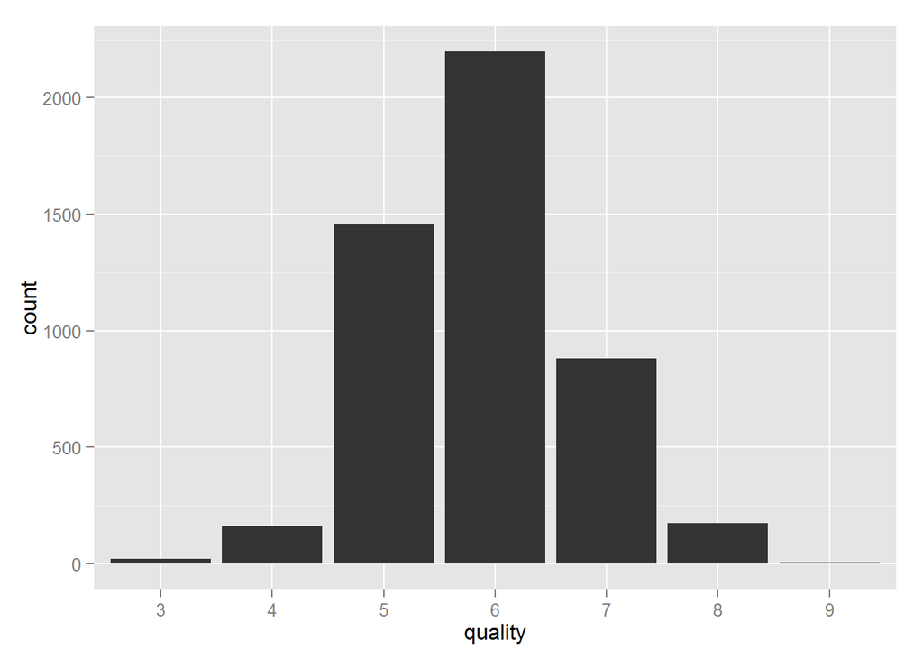

```
##
## FALSE  TRUE
##  2700  2198
```

As I might have guessed based on the summary, the most common wine quality rating is 6, with 2,198 observations. 5 and 7 are 2nd and 3rd most common. With so few observations at 3 and 9, those ratings can be considered very poor and very good, respectively.

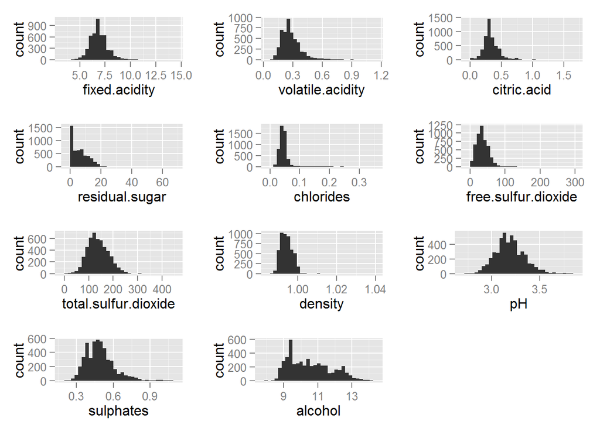

I want to adjust the binwidths on these charts so that I can more accurately follow the curve of the data.

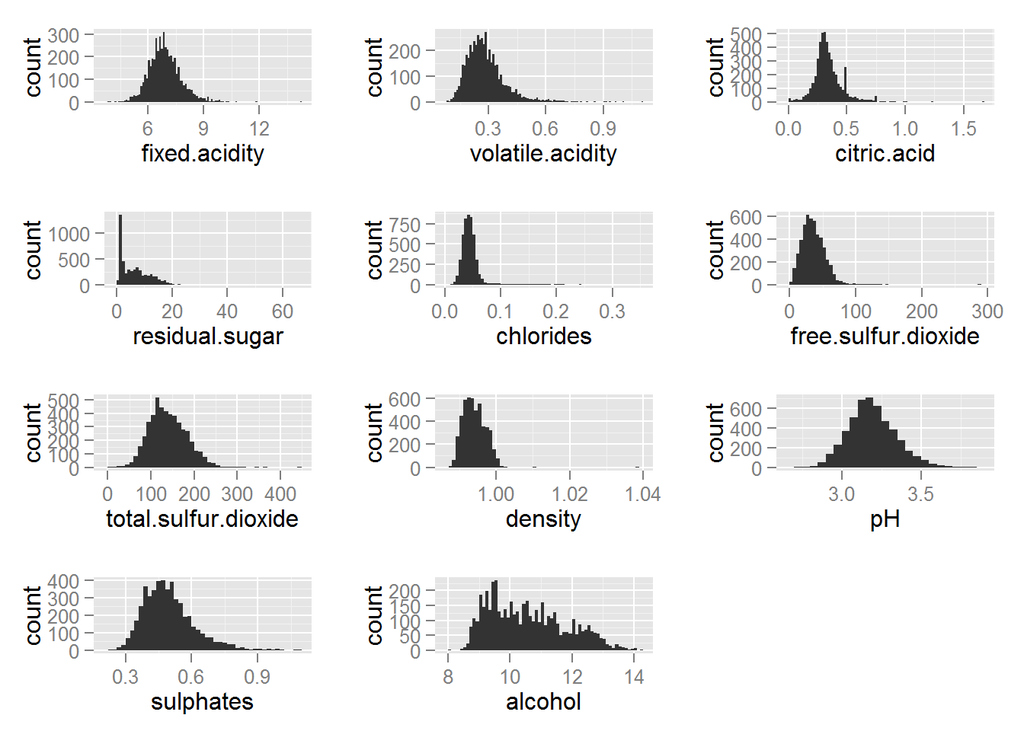

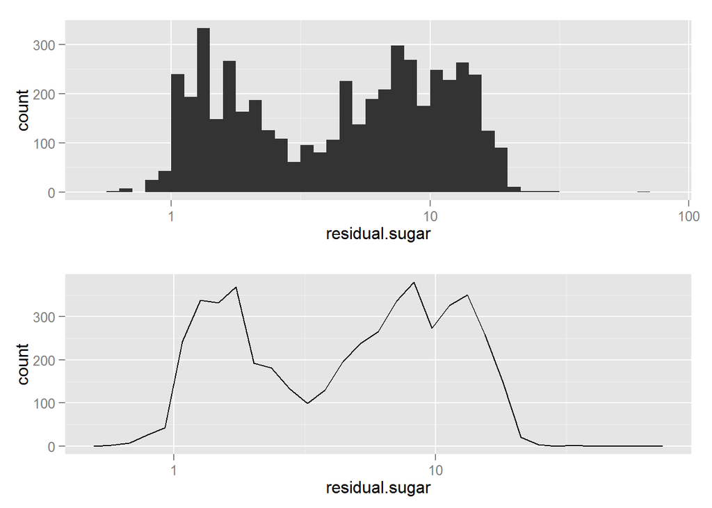

Now the residual sugar chart follows more of a normal distribution. It is worth noting that the curve does appear bimodal with two spikes. The frequency polygon makes the bimodality even more obvious.

I also noticed in the histograms that several of the features have outliers that shift the bell curves to the left side of the plot, including residual sugar, chlorides, free sulfur dioxide, and density.

```
##  99%
## 0.16
```

```
##      99%
## 1.000302
```

The 99th percentile for chlorides is 0.16 and 99th percentile for density is 1.000. I would like to take a look at the charts with the bottom and top 1% removed from each variable.

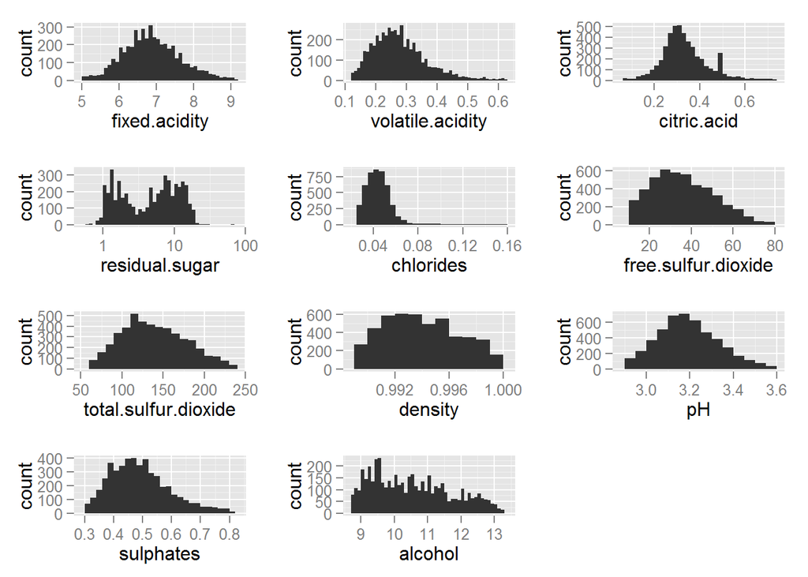

Now I can read the charts more cleanly without the outliers, and ignoring the outliers could potentially lead to a better model.

As noted earlier, citric acid is the only variable with some 0 values. However, its histogram shows that the 0 values are a very small percentage of the total dataset. This is noteworthy because we can consider all variables to contribute a nonzero value to the entries in the dataset.

After reading the variable descriptions for the white wine data, I would like to create a new field for “bound” sulfur dioxide. The data currently has features for free sulfur dioxide and total sulfur dioxide, so I can subtract the free from the total and use that as an additional feature going forward.

```
##    Min. 1st Qu.  Median    Mean 3rd Qu.    Max.
##     4.0    78.0   100.0   103.1   125.0   331.0
```

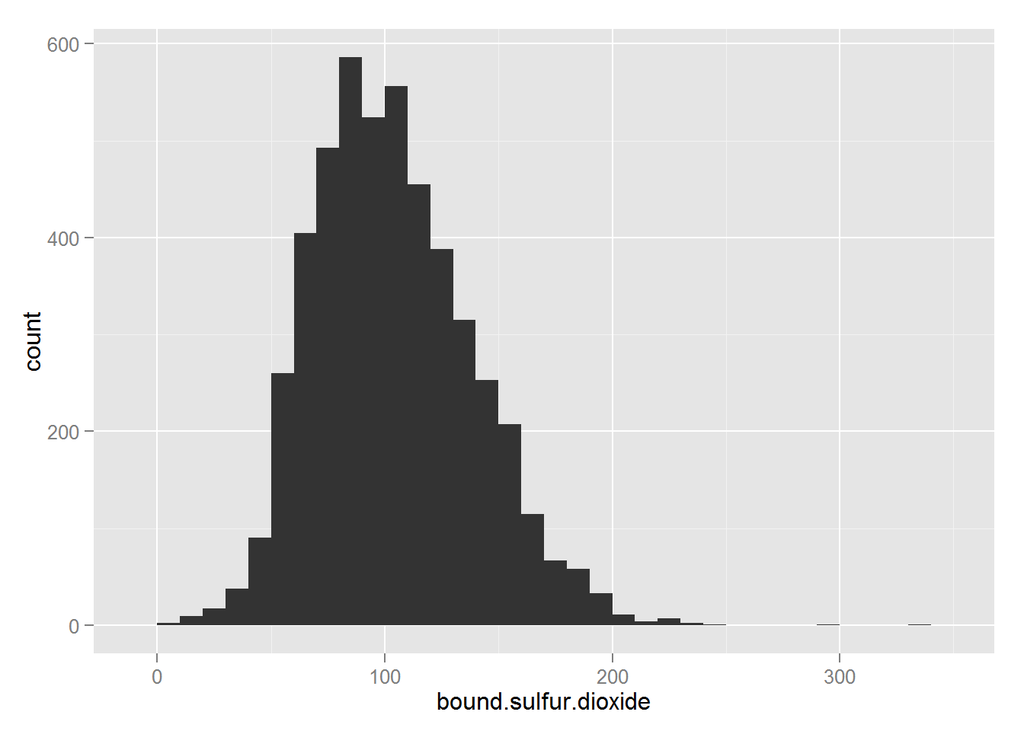

As expected, the bound sulfur dioxide is always greater than zero. The median is 100 and the mean is 103.1.

# Univariate Analysis

### What is the structure of your dataset?

There are 4,898 white wine observations in the dataset with 11 quantitative features (fixed acidity, volatile acidity, citric acid, residual sugar, chlorides, free sulfur dioxide, total sulfur dioxide, density, pH, sulphates, and alcohol). All of these features are number ranges so none are factor variables.

The final variable of quality can be considered an ordered factor because it scores the wine from 0 to 10. Despite that potential range, the actual quality values in this dataset range from 3 to 9. The median quality is 6 and the mean is 5.878, so a 6 rating is actually closer to average than a 5 for this dataset.

### What is/are the main feature(s) of interest in your dataset?

I’d like to determine a predictive model for the quality of the wine based on the inputs. Therefore, the quality is certainly a main feature. I also believe that the alcohol level will play a significant role since different alcohol levels will affect the quality.

### What other features in the dataset do you think will help support your investigation into your feature(s) of interest?

Any of the 11 variables could play a role in the quality model. It is logical at this point to predict that some of the features that have the highest median/mean g/L will have the highest impact on the quality. With that in mind, I will be sure to take a close look at fixed acidity and residual sugar. I think that sulphates and pH may also play a significant role.

### Did you create any new variables from existing variables in the dataset?

In the interest of getting to know the dataset as much as possible, I created one new variable for sulfur dioxide. Since the white wine data only included free and total sulfur dioxide totals, I added a new variable for the “bound” sulfur dioxide by subtracting the free from the total. I will include this variable in my analysis going forward.

Later on in this analysis, I will convert some of the continuous variables into categorical ordered factors with discrete ranges. This will help me with effective visualizations.

### Of the features you investigated, were there any unusual distributions? Did you perform any operations on the data to tidy, adjust, or change the form of the data? If so, why did you do this?

One of the first adjustments I made to the data was to change the data type of quality to be an ordered factor. It can be analyzed more naturally in this way because the quality ratings can be thought of as discrete levels. This also preps it for future analysis such as box plots.

The residual sugar histogram was the only histogram that did not look normal because it was too long-tailed, so I applied a log transform to the x-axis. As expected, the distribution became more normal, but it also took on a bimodal shape. This means that the measurements for residual sugar loosely group together at a lower value and a higher value. This may have an impact on the quality and warrants further investigation.

Another adjustment I made to the data when evaluating the histograms was to adjust the binwidths and remove the outliers. Adjusting the binwidths allowed me to see the distribution of the data more clearly. Also, after removing the bottom and top 1% of each variable, I could get a much clearer feel for the shape of the main parts of the histogram distribution.

# Bivariate Plots Section

[figure not shown]

I quickly analyzed all of the variables using ggpairs in order to see what jumps out immediately. The correlations are precise since I used all 4,898 observations in this analysis. Note: The chart is difficult to read since there are so many features, so I included a PNG image with my project submission.

Here are the correlations of note involving quality. I had to utilize the integer version of the quality variable in order to calculate the correlations.

- Quality and alcohol: 0.436
- Quality and density: -0.307
- Quality and chlorides: -0.210

None of those correlations can be considered strong.

I want to take a look at the quality boxplots for each of our variables, while focusing mainly on the correlating variables identified above.

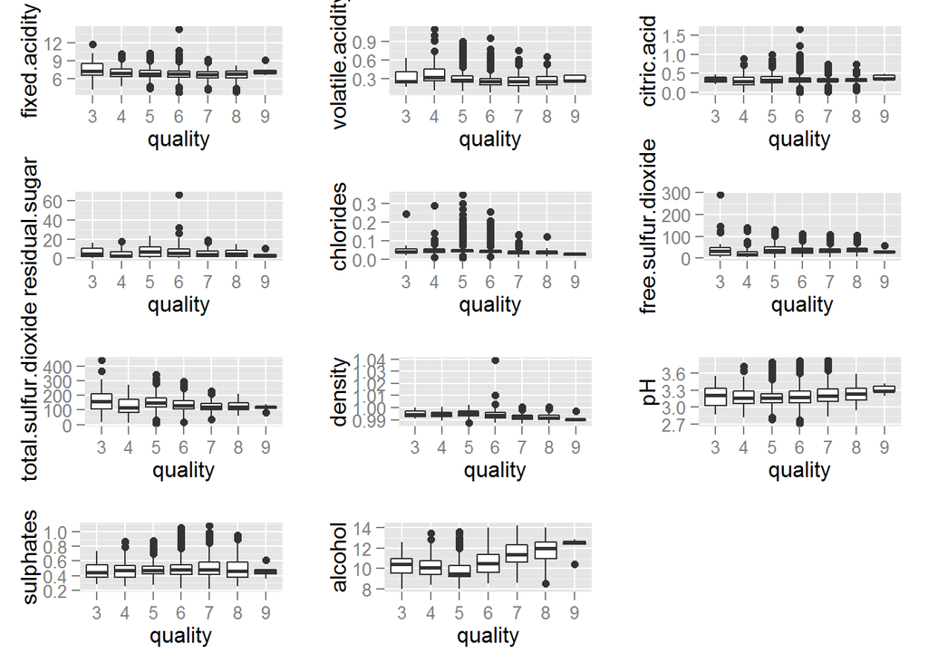

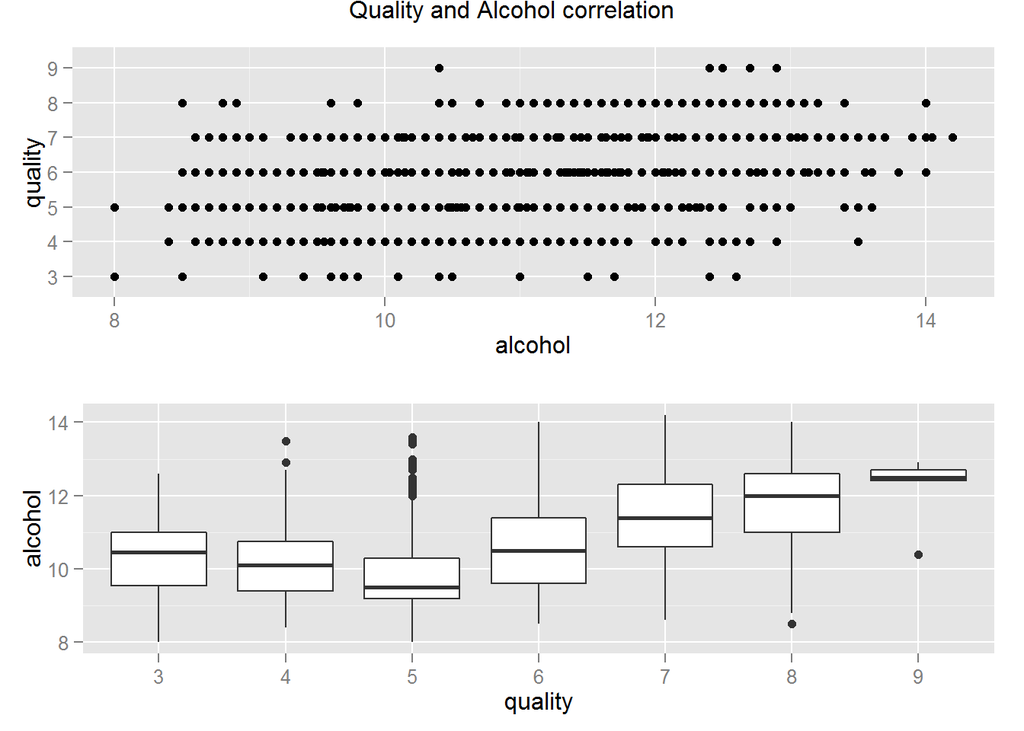

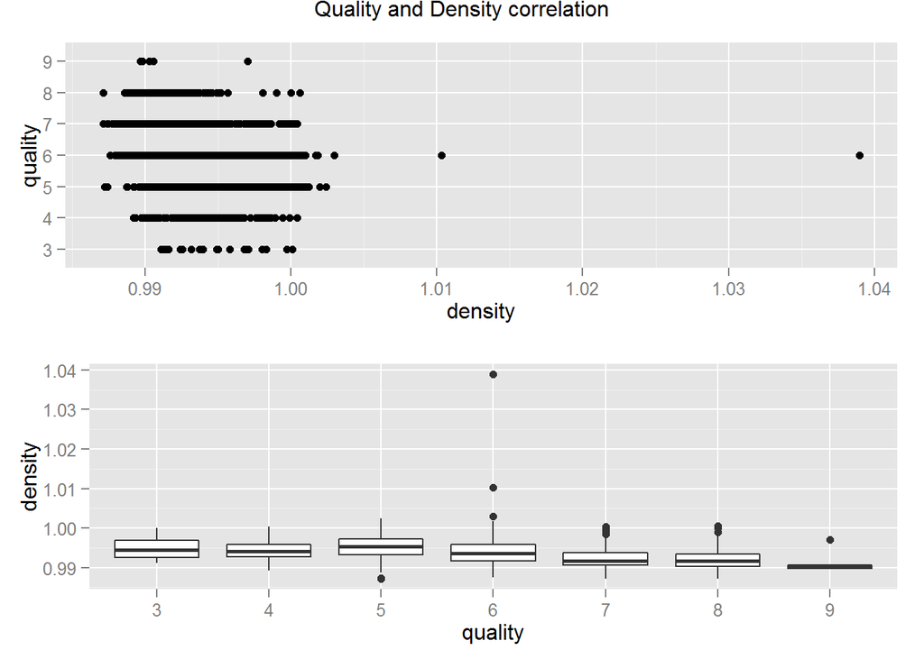

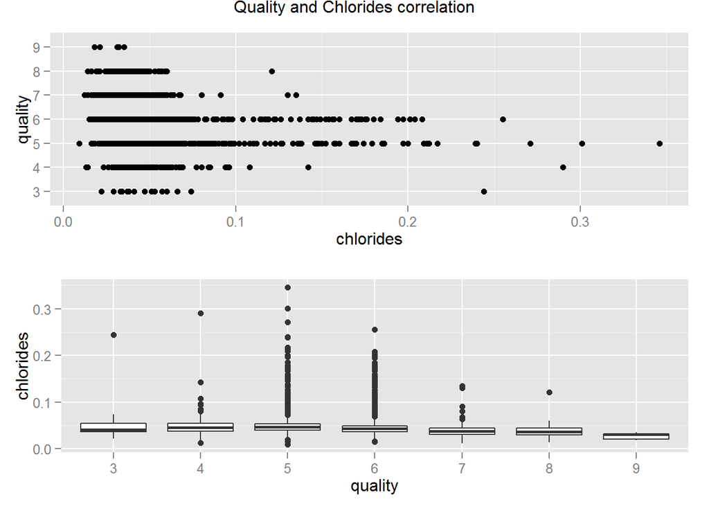

I want to make some adjustments to these plots, including:

- Adding jitter in order to visualize trends
- Changing transparency in order to prevent overplotting
- Limiting the axes to remove outliers

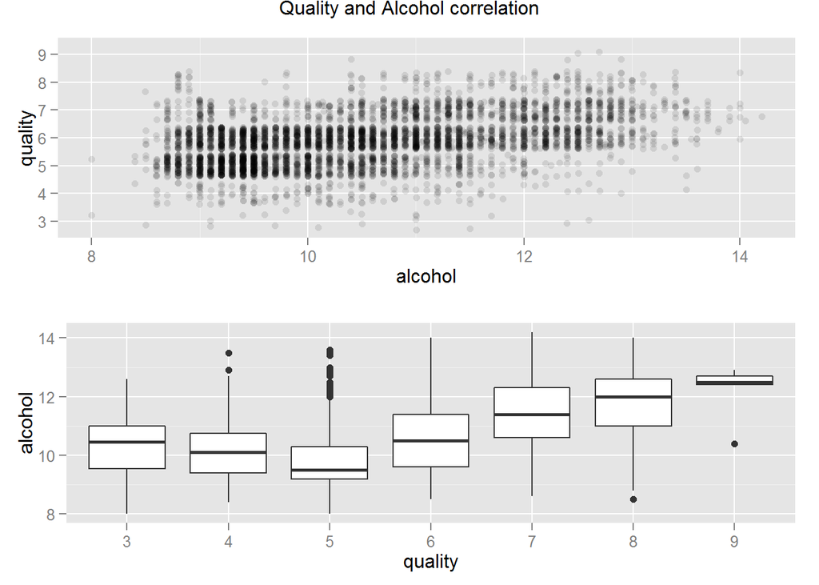

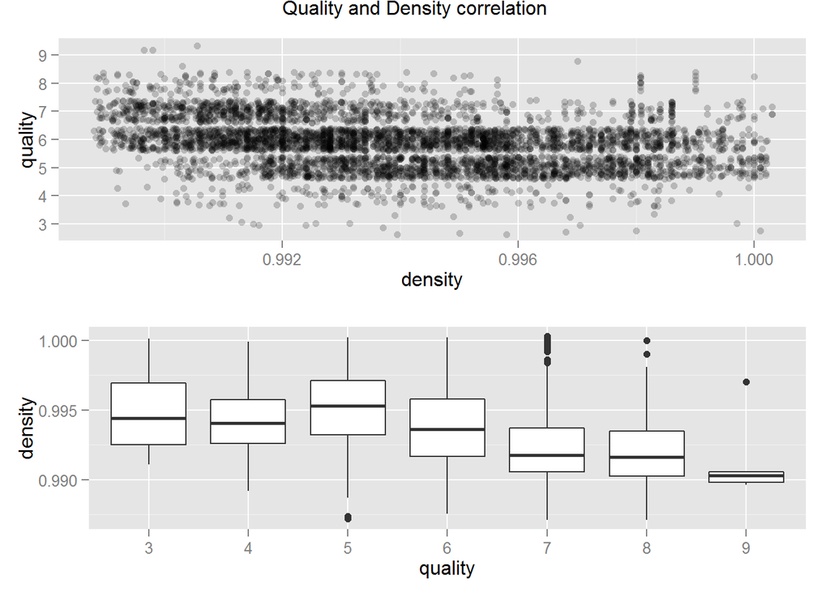

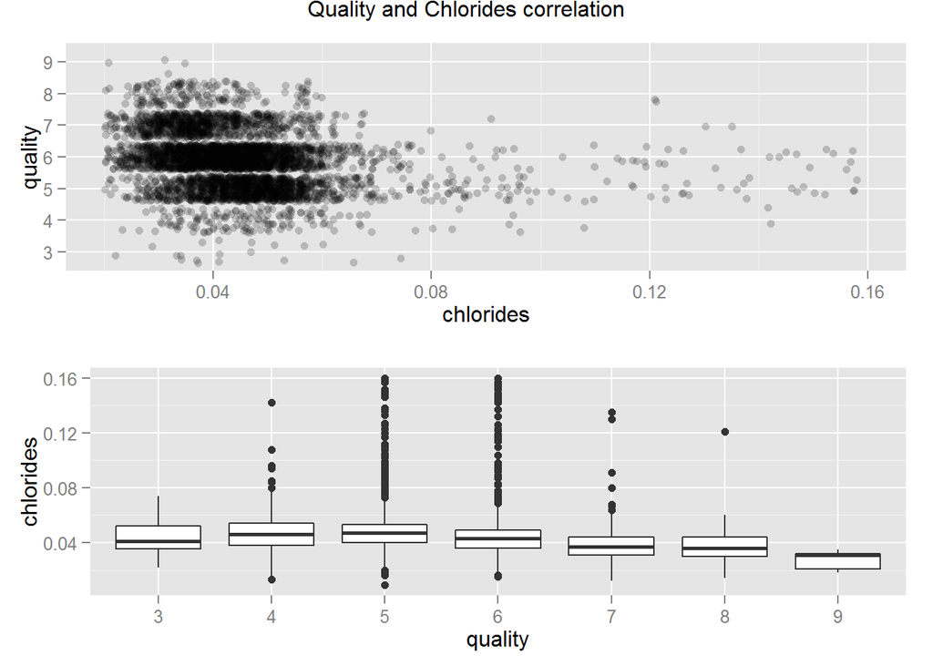

There are several noteworthy points about these charts. The strongest correlation is between quality and alcohol. As the jitter scatterplot shows, there is a slight upward trend from left to right where the plot is most dense. This explains the 0.436 correlation between the two variables. The boxplot also supports this assertion because as quality increases from 5 to 9, the median and quartile ranges for alcohol also steadily increase. This means that the judges probably like alcohol!

Density and quality have a loose negative correlation of 0.307. After removing the top 1% of outliers, the jitter chart shows a downward trend from left to right. Again, the boxplot supports this assertion because as quality increases from 5 to 9, the quartile ranges for alcohol steadily decrease. We now know that higher quality ratings are associated with lower density values.

The final correlation that I noted for quality was related to chlorides. This correlation is weak since it is only -0.210. However, this is still stronger than any of the other variables besides density and alcohol. The jitter chart shows that if the chloride level is above ~0.08, the majority of the quality ratings are between 4 and 6. There is a tie between these two variables but it is fairly weak.

In the multivariate analysis section, I will evaluate all of the features that correlate with the quality in a single visualization.

I want to continue evaluating the relationship between alcohol and quality since this will help my end goal of a predictive model for quality.

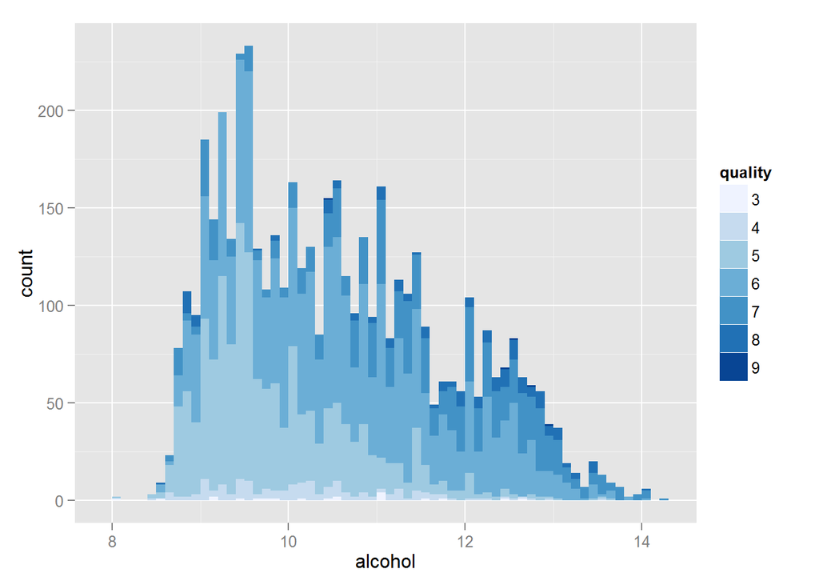

```
## wines$quality: 3
##    Min. 1st Qu.  Median    Mean 3rd Qu.    Max.
##    8.00    9.55   10.45   10.34   11.00   12.60
## --------------------------------------------------------
## wines$quality: 4
##    Min. 1st Qu.  Median    Mean 3rd Qu.    Max.
##    8.40    9.40   10.10   10.15   10.75   13.50
## --------------------------------------------------------
## wines$quality: 5
##    Min. 1st Qu.  Median    Mean 3rd Qu.    Max.
##   8.000   9.200   9.500   9.809  10.300  13.600
## --------------------------------------------------------
## wines$quality: 6
##    Min. 1st Qu.  Median    Mean 3rd Qu.    Max.
##    8.50    9.60   10.50   10.58   11.40   14.00
## --------------------------------------------------------
## wines$quality: 7
##    Min. 1st Qu.  Median    Mean 3rd Qu.    Max.
##    8.60   10.60   11.40   11.37   12.30   14.20
## --------------------------------------------------------
## wines$quality: 8
##    Min. 1st Qu.  Median    Mean 3rd Qu.    Max.
##    8.50   11.00   12.00   11.64   12.60   14.00
## --------------------------------------------------------
## wines$quality: 9
##    Min. 1st Qu.  Median    Mean 3rd Qu.    Max.
##   10.40   12.40   12.50   12.18   12.70   12.90
```

The chart above reinforces my hypothesis, because as the alcohol content increases, the histogram for the “5” quality ratings tail off significantly, and they are replaced with higher ratings of 7 and 8.

The summary above provides the IQR values that were displayed in the boxplot.

I want to take the same approach with density:

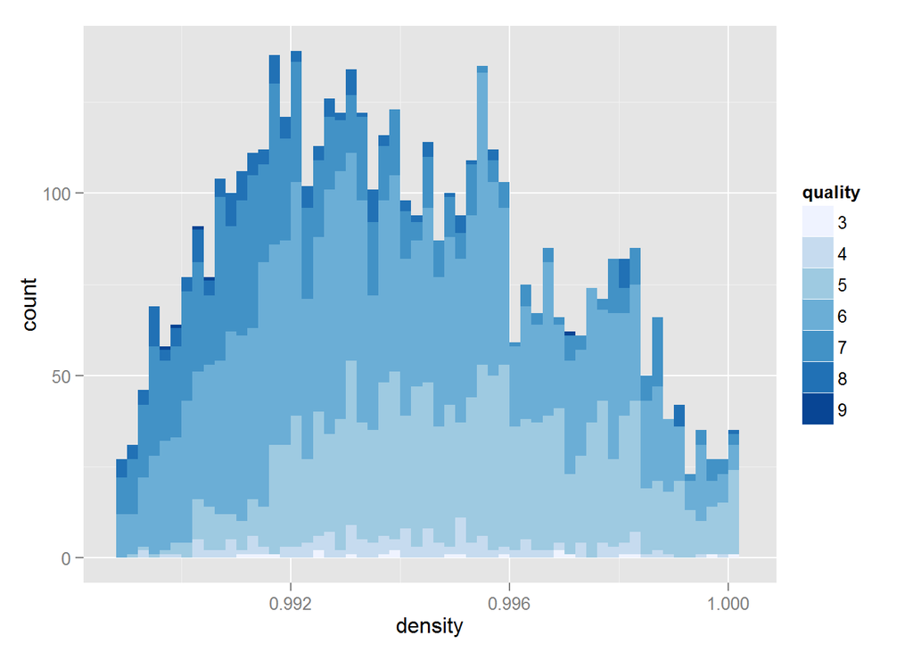

I also want to take a closer look at the density data after grouping by quality.

```
## Source: local data frame [7 x 6]
##
##   quality mean_density median_density min_density max_density    n
## 1       3    0.9948840       0.994425     0.99110     1.00010   20
## 2       4    0.9942767       0.994100     0.98920     1.00040  163
## 3       5    0.9952626       0.995300     0.98722     1.00241 1457
## 4       6    0.9939613       0.993660     0.98758     1.03898 2198
## 5       7    0.9924524       0.991760     0.98711     1.00040  880
## 6       8    0.9922359       0.991640     0.98713     1.00060  175
## 7       9    0.9914600       0.990300     0.98965     0.99700    5
```

The median data again show that as quality increases, there is a downward trend of the density values.

Since alcohol has the highest correlation of any of the features, I want to test a linear model for the alcohol and quality scatterplot.

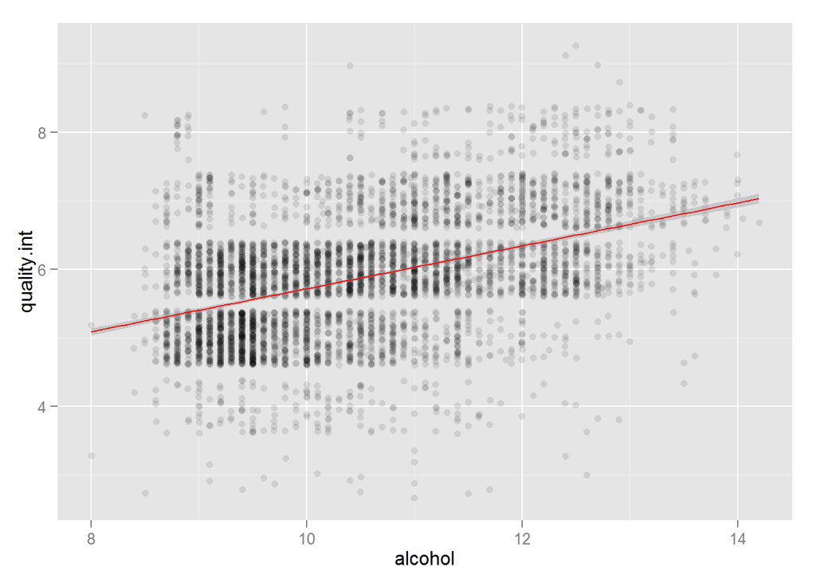

```
##
## Call:
## lm(formula = I(alcohol) ~ I(quality), data = wines)
##
## Residuals:
##     Min      1Q  Median      3Q     Max
## -3.1360 -0.7754 -0.1088  0.7321  3.7912
##
## Coefficients:
##              Estimate Std. Error t value Pr(>|t|)
## (Intercept)  10.86651    0.07985 136.084  < 2e-16 ***
## I(quality).L  1.89572    0.31166   6.083 1.27e-09 ***
## I(quality).Q  0.74120    0.29723   2.494   0.0127 *
## I(quality).C -0.49302    0.22800  -2.162   0.0306 *
## I(quality)^4 -0.02540    0.14793  -0.172   0.8637
## I(quality)^5  0.40330    0.08266   4.879 1.10e-06 ***
## I(quality)^6 -0.06782    0.04030  -1.683   0.0925 .
## ---
## Signif. codes:  0 '***' 0.001 '**' 0.01 '*' 0.05 '.' 0.1 ' ' 1
##
## Residual standard error: 1.088 on 4891 degrees of freedom
## Multiple R-squared:  0.2199, Adjusted R-squared:  0.2189
## F-statistic: 229.7 on 6 and 4891 DF,  p-value: < 2.2e-16
```

Despite the correlation between alcohol and quality, the R^2 value is too low for this linear model to be considered a good fit. The relationship is too scattered to be considered linear. The box plot does reflect a slight increase in quality at the low end of the alcohol scale that must not be ignored. I must consider a non-linear model or bring in additional variables in order to improve the predictive model.

In addition to evaluating the correlations related to quality, I also want to understand how the other variables work with each other. Here are the correlations of note that do not involve quality:

- Total sulfur dioxide and residual sugar: 0.401
- Total sulfur dioxide and free sulfur dioxide: 0.616
- Total sulfur dioxide and bound sulfur dioxide: 0.922
- Total sulfur dioxide and alcohol: -0.449
- Bound sulfur dioxide and density: 0.504
- Bound sulfur dioxide and alcohol: -0.427
- Density and residual sugar: 0.839
- Alcohol and density: -0.780
- Residual sugar and alcohol: -0.451
- Fixed acidity and pH: -0.426

It should come as no surprise that total sulfur dioxide correlates with at least a few variables, because it is closely related to both free and bound sulfur dioxide.

[output not shown]

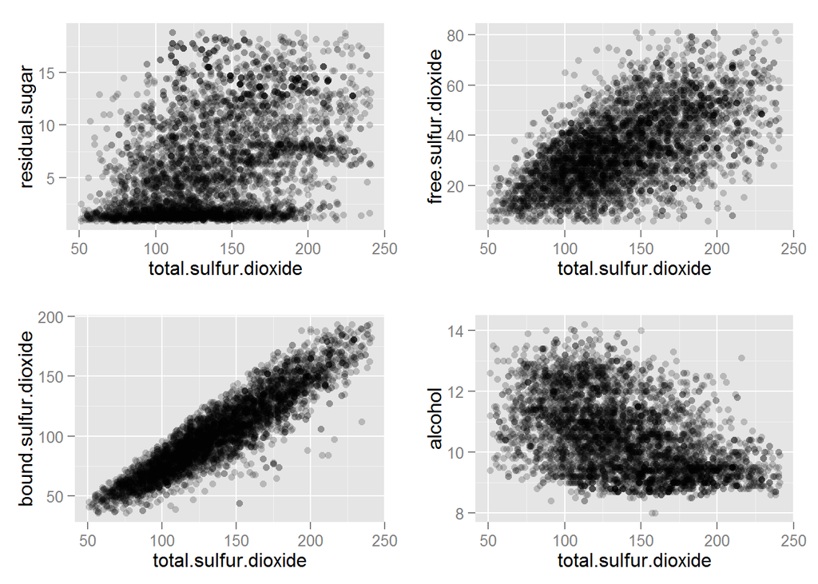

The total sulfur dioxide correlations are evident in the visualizations above.

Density, alcohol, and residual sugar all appear to have a strong correlation with each other, so I want to take a look at those plots.

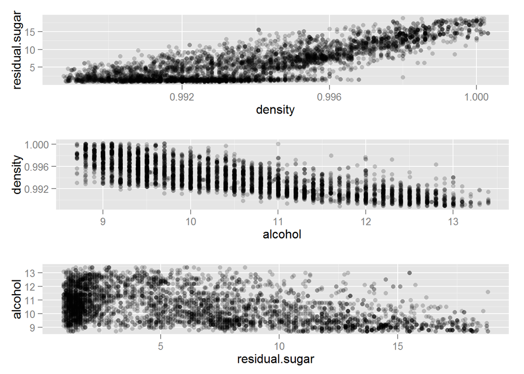

The correlations are apparent in the above charts. Sugar must be more dense than other ingredients in the wine, because higher levels of sugar have higher density. Alcohol must be less dense than other ingredients, because higher levels of alcohol have less density. Thirdly, alcohol and sugar may offset each other during the wine-making process, because lower levels of alcohol tend to have higher levels of sugar (and vice versa). In the multivariate section, I will create a plot that evaluates the relationship between these variables in a single view.

The last correlation I want to highlight is the correlation between pH and fixed acidity. This correlation makes logical sense because as fixed acidity increases, the pH value becomes more acidic.

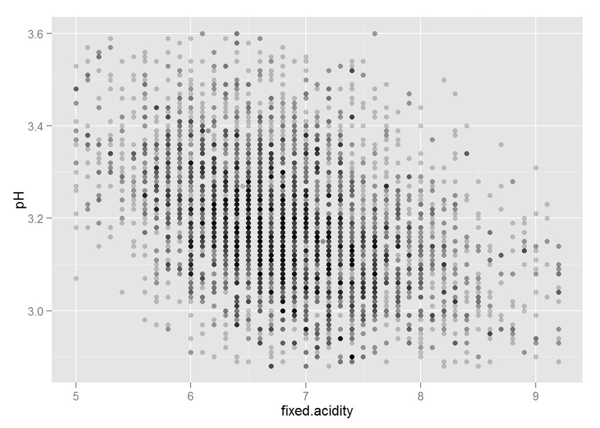

# Bivariate Analysis

### Did you observe any interesting relationships between the other features (not the main feature(s) of interest)?

In addition to evaluating quality, I also examined the relationships between the other variables in the white wine data. I quickly discovered that total sulfur dioxide has the most correlations that are 0.4 or stronger. This makes sense because the free and bound sulfur dioxides are closely related.

I discovered an interesting relationship between alcohol, density, and residual sugar. As the alcohol level increases, the density level tends to decrease. Also, as the residual sugar level increases, the density tends to increase. Therefore sugar is one of the more dense components and alcohol is one of the less dense components. Finally, as sugar increases, the alcohol level tends to decrease, especially with sugar levels above 5 g/dm^3. I would venture a theory that not as much alcohol is created during the fermentation process when there is significant sugar remaining.

Since some of these variables correlate to each other, I may need to exclude some of them from the predictive model for quality. This is because strongly correlated variables would not generate new insight for the predictive model.

### What was the strongest relationship you found?

The strongest relationship I found was between total and bound sulfur dioxide, because the correlation was 0.922. This is logical since I used the total sulfur dioxide variable to calculate the bound variable. The next strongest tier of relationships was between density and residual sugar and density and alcohol, which I discussed in the answer to the previous question.

# Multivariate Plots Section

In order to evaluate additional variables in new and meaningful ways, I want to convert several of the numeric variables of interest into ordered factors.

```
## 'data.frame':    4898 obs. of  19 variables:
##  $ fixed.acidity        : num  7 6.3 8.1 7.2 7.2 8.1 6.2 7 6.3 8.1 ...
##  $ volatile.acidity     : num  0.27 0.3 0.28 0.23 0.23 0.28 0.32 0.27 0.3 0.22 ...
##  $ citric.acid          : num  0.36 0.34 0.4 0.32 0.32 0.4 0.16 0.36 0.34 0.43 ...
##  $ residual.sugar       : num  20.7 1.6 6.9 8.5 8.5 6.9 7 20.7 1.6 1.5 ...
##  $ chlorides            : num  0.045 0.049 0.05 0.058 0.058 0.05 0.045 0.045 0.049 0.044 ...
##  $ free.sulfur.dioxide  : num  45 14 30 47 47 30 30 45 14 28 ...
##  $ total.sulfur.dioxide : num  170 132 97 186 186 97 136 170 132 129 ...
##  $ density              : num  1.001 0.994 0.995 0.996 0.996 ...
##  $ pH                   : num  3 3.3 3.26 3.19 3.19 3.26 3.18 3 3.3 3.22 ...
##  $ sulphates            : num  0.45 0.49 0.44 0.4 0.4 0.44 0.47 0.45 0.49 0.45 ...
##  $ alcohol              : num  8.8 9.5 10.1 9.9 9.9 10.1 9.6 8.8 9.5 11 ...
##  $ quality              : Ord.factor w/ 7 levels "3"<"4"<"5"<"6"<..: 4 4 4 4 4 4 4 4 4 4 ...
##  $ quality.int          : int  6 6 6 6 6 6 6 6 6 6 ...
##  $ bound.sulfur.dioxide : num  125 118 67 139 139 67 106 125 118 101 ...
##  $ alcohol.bucket       : Ord.factor w/ 4 levels "(7,9.5]"<"(9.5,10.4]"<..: 1 1 2 2 2 2 2 1 1 3 ...
##  $ density.bucket       : Ord.factor w/ 4 levels "(0.987,0.992]"<..: 4 3 3 3 3 3 3 4 3 3 ...
##  $ chlorides.bucket     : Ord.factor w/ 4 levels "(0.008,0.036]"<..: 3 3 3 4 4 3 3 3 3 3 ...
##  $ residual.sugar.bucket: Ord.factor w/ 2 levels "(0.5,5.2]"<"(5.2,65.8]": 2 1 2 2 2 2 2 2 1 1 ...
##  $ quality.bucket       : Ord.factor w/ 3 levels "(2,5]"<"(5,7]"<..: 2 2 2 2 2 2 2 2 2 2 ...
```

I split the following fields into categorical variables as shown above. I split alcohol, density, and chlorides using the interquartile ranges.

- alcohol
- density
- chlorides
- residual sugar
- quality

I split residual sugar only into two categories (using the median) since I learned earlier in my exploration that the sugar’s distribution is bimodal. I split quality into three buckets as described below:

- Less than or equal to 5: “Poor” quality
- 6 or 7: “Average” quality
- Greater than or equal to 8: “Good”" quality

As mentioned earlier, I want to use multivariate analysis methods in order to evaluate the relationship between density, alcohol, and residual sugar in a single plot. I will use the newly-created categorical variable for sugar to accomplish this.

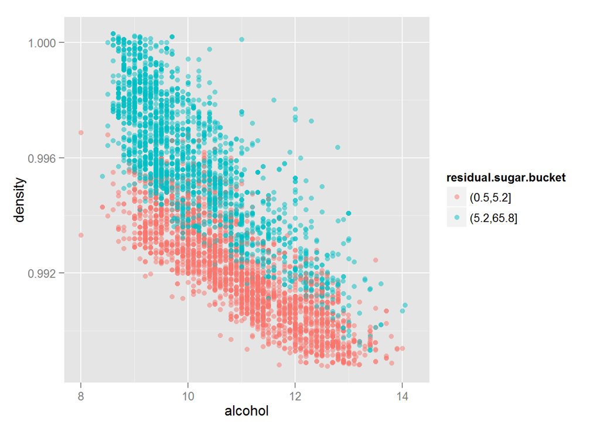

The chart above demonstrates the relationship between the three features. As alcohol increases, density decreases. Higher density levels are associated with higher levels of residual sugar (blue dots), and higher alcohol levels are associated with lower levels of residual sugar (red dots).

I also want to use multivariate analysis methods to visualize the relationship between all of the variables that have a correlation with quality stronger than 0.2: alcohol, density, and chlorides.

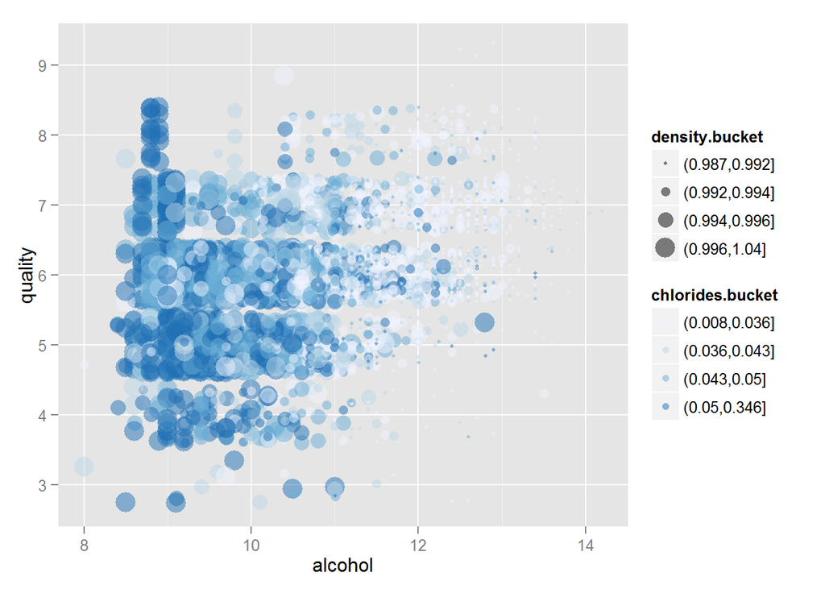

The above plot demonstrates the relationship between quality and the 3 correlating variables in a single visualization, albeit the chart is a little too crowded to easily interpret. The positive correlation between quality and alcohol is evident as the scatterplot tends to slope upwards to the right. Secondly, there is a larger concentration of higher levels of chlorides at lower qualities, since there is more dark blue towards the bottom of the chart. Finally, the negative correlation between quality and density is evident in that there is a greater concentration of larger dots at poor and average quality levels.

I want to further investigate these relationships by using the median function to evaluate the density and chlorides features against quality for different levels of alcohol. This will help me determine if the trends are consistent across all quality levels. The alcohol bucket field that I created will prove useful.

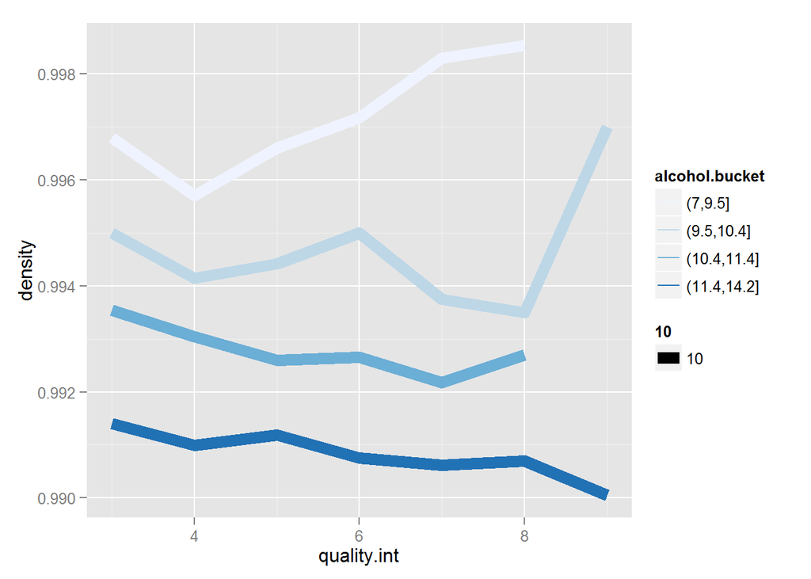

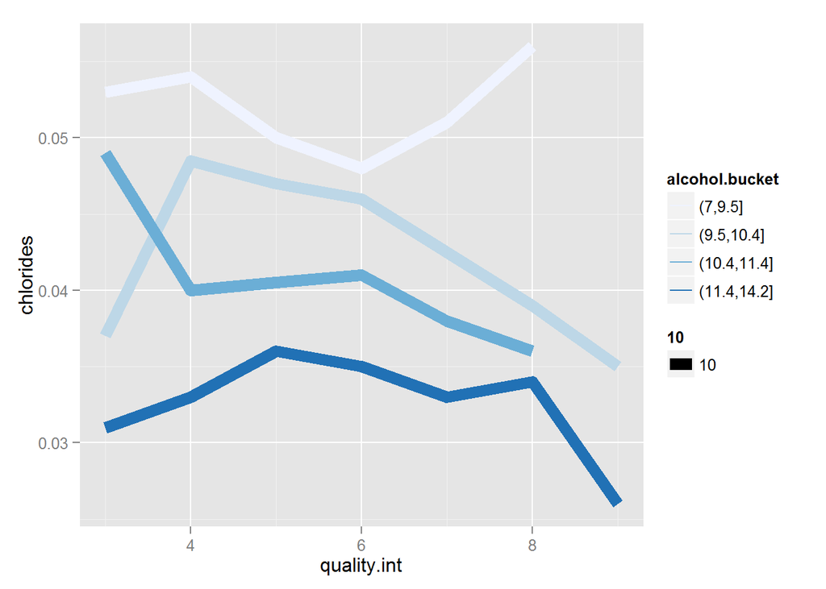

The first chart above clearly shows that the median density decreases as the alcohol level increases. This trend is very consistent for each quality level, because the lines never overlap and each line has similar slope and structure. The second chart is a bit more involved. In general, the median level of chlorides is higher when the alcohol level is lower. However, this is not the case for the lowest quality level of 3. This anomaly may only be noise in the data though because there are only 20 samples that have a quality rating of 3. Another interesting note about this chart is that for the lowest alcohol bucket, the level of chlorides *increases* as the quality *increases* from 6 to 8. For the other 3 alcohol buckets, the level of chlorides *decreases* as the quality *increases*.

I now feel that I have a good sense of the main features of interest in the white wine dataset. Before I attempt to create a model for quality, I want to ensure I am not ignoring the features that do not correlate with quality. Even though the other features do not have a strong or even a weak correlation, there may be valuable insights when plotting the data.

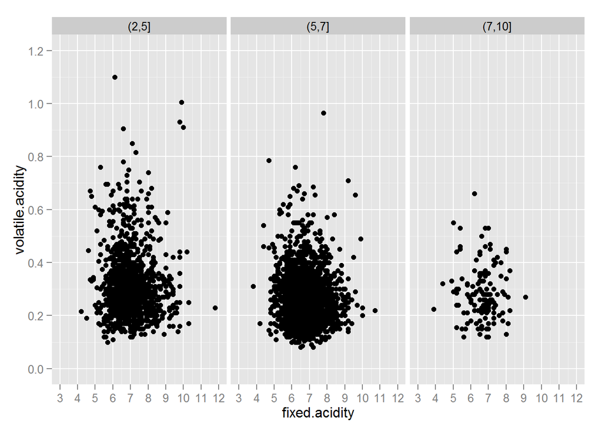

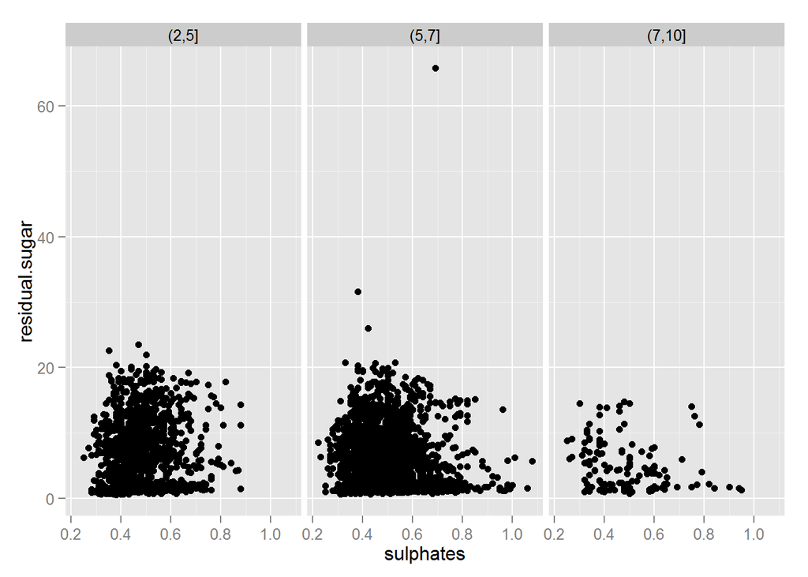

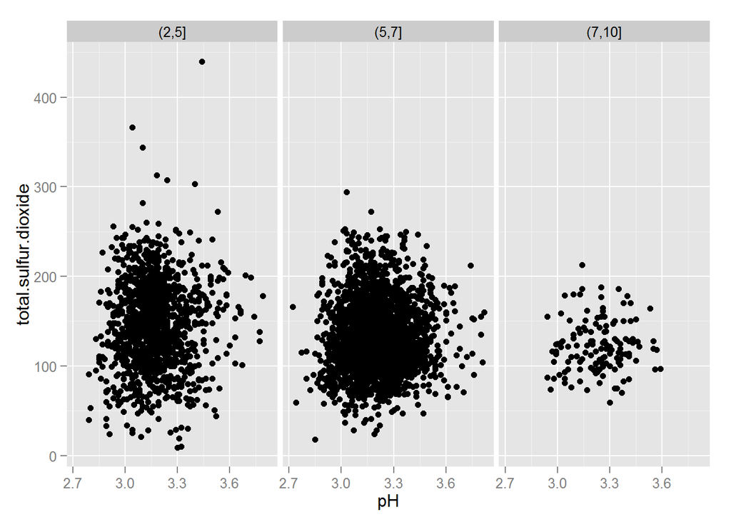

I used facet wrap to split the charts into 3 scatterplots based on poor quality, average quality, and good quality. Plotting the variables against each other in this manner allows for a quick review of the information.

Unfortunately, none of the variables had a strong enough correlation with quality that it could truly be called a linear relationship. I realized this when the linear model for alcohol vs quality produced such a low R2 value. What I do know is that these features have at least a small degree of correlation with quality:

- Alcohol
- Density
- Chlorides

I also know that these features may have an impact on quality since there are some noticeable trends when plotting against quality:

- Fixed acidity
- Volatile acidity
- pH
- Total sulfur dioxide

I will build my model using these features and the “lm” function. I will also bring in the rest of the features in order to evaluate their impact on the model.

```
##
## Calls:
## m1: lm(formula = quality.int ~ alcohol, data = wines)
## m2: lm(formula = quality.int ~ alcohol + density, data = wines)
## m3: lm(formula = quality.int ~ alcohol + density + chlorides, data = wines)
## m4: lm(formula = quality.int ~ alcohol + density + chlorides + fixed.acidity,
##     data = wines)
## m5: lm(formula = quality.int ~ alcohol + density + chlorides + fixed.acidity +
##     volatile.acidity, data = wines)
## m6: lm(formula = quality.int ~ alcohol + density + chlorides + fixed.acidity +
##     volatile.acidity + pH, data = wines)
## m7: lm(formula = quality.int ~ alcohol + density + chlorides + fixed.acidity +
##     volatile.acidity + pH + total.sulfur.dioxide, data = wines)
## m8: lm(formula = quality.int ~ alcohol + density + chlorides + fixed.acidity +
##     volatile.acidity + pH + total.sulfur.dioxide + log(residual.sugar),
##     data = wines)
## m9: lm(formula = quality.int ~ alcohol + density + chlorides + fixed.acidity +
##     volatile.acidity + pH + total.sulfur.dioxide + log(residual.sugar) +
##     citric.acid, data = wines)
## m10: lm(formula = quality.int ~ alcohol + density + chlorides + fixed.acidity +
##     volatile.acidity + pH + total.sulfur.dioxide + log(residual.sugar) +
##     citric.acid + free.sulfur.dioxide, data = wines)
## m11: lm(formula = quality.int ~ alcohol + density + chlorides + fixed.acidity +
##     volatile.acidity + pH + total.sulfur.dioxide + log(residual.sugar) +
##     citric.acid + free.sulfur.dioxide + sulphates, data = wines)
##
## ==============================================================================================================================================
##                           m1         m2         m3         m4         m5         m6         m7         m8         m9        m10        m11
## ----------------------------------------------------------------------------------------------------------------------------------------------
## (Intercept)            2.582***  -22.492*** -21.150*** -31.387*** -47.652*** -47.870*** -43.543***  41.731***  42.639***  37.700***  47.757***
##                       (0.098)     (6.165)    (6.162)    (6.355)    (6.195)    (6.222)    (6.510)   (11.223)   (11.284)   (11.294)   (11.437)
## alcohol                0.313***    0.360***   0.343***   0.356***   0.405***   0.406***   0.408***   0.310***   0.308***   0.310***   0.296***
##                       (0.009)     (0.015)    (0.015)    (0.015)    (0.015)    (0.015)    (0.015)    (0.018)    (0.019)    (0.019)    (0.019)
## density                           24.728***  23.671***  34.437***  50.909***  51.237***  46.805*** -39.975*** -40.902*** -36.049**  -46.226***
##                                   (6.079)    (6.074)    (6.293)    (6.137)    (6.199)    (6.501)   (11.351)   (11.414)   (11.422)   (11.567)
## chlorides                                    -2.382***  -2.421***  -1.323*    -1.334*    -1.399**   -0.762     -0.808     -0.831     -0.818
##                                              (0.558)    (0.555)    (0.539)    (0.540)    (0.541)    (0.541)    (0.544)    (0.542)    (0.541)
## fixed.acidity                                           -0.087***  -0.101***  -0.103***  -0.103***  -0.027     -0.029     -0.020     -0.014
##                                                         (0.014)    (0.014)    (0.015)    (0.015)    (0.017)    (0.017)    (0.017)    (0.017)
## volatile.acidity                                                   -2.085***  -2.088***  -2.112***  -2.117***  -2.101***  -1.981***  -1.953***
```

[output cut: 10 more lines]

```
##                                                                                                                           (0.001)    (0.001)
## sulphates                                                                                                                             0.502***
##                                                                                                                                      (0.099)
## ----------------------------------------------------------------------------------------------------------------------------------------------
## R-squared                 0.190      0.192      0.195      0.202      0.256      0.256      0.257      0.270      0.270      0.274      0.278
## adj. R-squared            0.190      0.192      0.195      0.201      0.255      0.255      0.256      0.269      0.269      0.272      0.276
## sigma                     0.797      0.796      0.795      0.792      0.764      0.764      0.764      0.757      0.757      0.755      0.754
## F                      1146.395    583.290    396.315    309.222    336.912    280.734    241.554    225.827    200.787    184.336    170.797
## p                         0.000      0.000      0.000      0.000      0.000      0.000      0.000      0.000      0.000      0.000      0.000
## Log-likelihood        -5839.391  -5831.127  -5822.011  -5802.684  -5629.932  -5629.861  -5627.322  -5584.491  -5584.187  -5570.814  -5557.825
## Deviance               3112.257   3101.773   3090.247   3065.956   2857.136   2857.053   2854.093   2804.611   2804.262   2788.992   2774.238
## AIC                   11684.782  11670.255  11654.021  11617.368  11273.865  11275.722  11272.645  11188.982  11190.373  11165.629  11141.649
## BIC                   11704.272  11696.241  11686.504  11656.348  11319.341  11327.694  11331.114  11253.948  11261.836  11243.588  11226.105
## N                      4898       4898       4898       4898       4898       4898       4898       4898       4898       4898       4898
## ==============================================================================================================================================
```

None of the combinations of features that I tried led to a great predictor of white wine quality. The R2 value increases to 0.278 once all of the variables are included in the model, which is not a strong correlation and there are high residuals. This means that there either need to be additional contributing features or I need to evaluate non-linear transformations of these features.

# Multivariate Analysis

### Talk about some of the relationships you observed in this part of the investigation. Were there features that strengthened each other in terms of looking at your feature(s) of interest?

In this part of the investigation, I was able to:

- Visualize some relationships more concisely and effectively: I strengthened my insight into the relationship between density, alcohol, and residual sugar in a single plot.
- Evaluate some relationships at a deeper level: I determined that the relationship between density and alcohol stays consistent for all quality values. However, the relationship between chlorides and alcohol may change based on the quality.
- Investigate some new relationships: I found some noteworthy trends between quality and several variables, including the acidity features, total sulfur dioxide, and pH.

### Were there any interesting or surprising interactions between features?

From very early on in the analysis, I found it surprising that alcohol is positively correlated with the quality. As the boxplot for alcohol level and quality showed, higher quality levels are associated with steadily increasing levels of alcohol. Since alcohol itself is generally not considered tasty, this seemed a bit counterintuitive. I reasoned that a certain minimum threshold needs to be reached before the negative effect of the alcohol taste takes effect. I would also theorize that if the alcohol level continued to increase, the quality would start to dip sharply downwards.

I also found the relationship between sugar, density, and alcohol to be interesting and I explore that in detail in the Plot Three section below.

### OPTIONAL: Did you create any models with your dataset? Discuss the strengths and limitations of your model.

I did fit a linear model to my dataset. The purpose is to predict the quality of the white wine based on the other features in the data. It includes features that have some correlation with the level of quality.

The model grew steadily stronger as I added additional features to the data. However, the statistics used to evaluate the fit reflect that a linear model may not be the best way to characterize this data. The R2 values were low and the residuals were high. In fact, it is not much better than simply using alcohol as the predictor, which I tried in the bivariate plots section. The model may also suffer from the fact that some of the features that were used correlate with each other.

In order to improve the model, I would need to bring in additional data or investigate new ways to transform the model in order to fine tune it. There is likely a better method than linear for this prediction model. I could also attempt to fit a unique linear model to different portions of the quality range.

# Final Plots and Summary

### Plot One

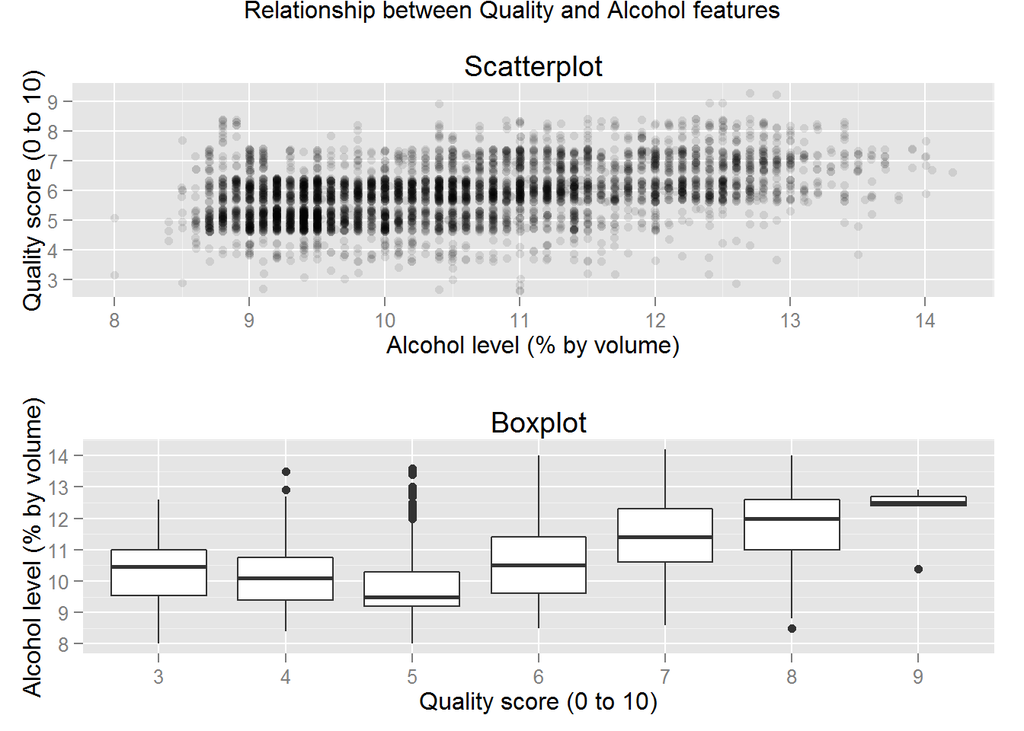

### Description One

This plot represents a key finding in my analysis. The strongest correlation between my main feature of interest (quality) and any other feature was alcohol at 0.436. This chart helps to visualize that relationship. In the scatterplot at the top, the concentration of points has an upward trend from left to right, which shows that as the alcohol level increases, the quality level also increases. I used jitter and changed the transparency in order to visualize this trend. The boxplot allows me to evaluate this relationship more precisely by showing that as quality increases from 3 to 5, the median alcohol level actually decreases. However, as quality increases above 5, the median alcohol level steadily increases from 9.5% to 12.5%.

This downward trend followed by an upward trend leads me to believe that there is a minimum threshold of alcohol content that needs to be reached for the wine to start having a positive effect on the quality. Once that threshold is reached, the quality increases with the alcohol content. If the alcohol level continued to increase above 12.5%, it would eventually start having a negative effect on the quality.

### Plot Two

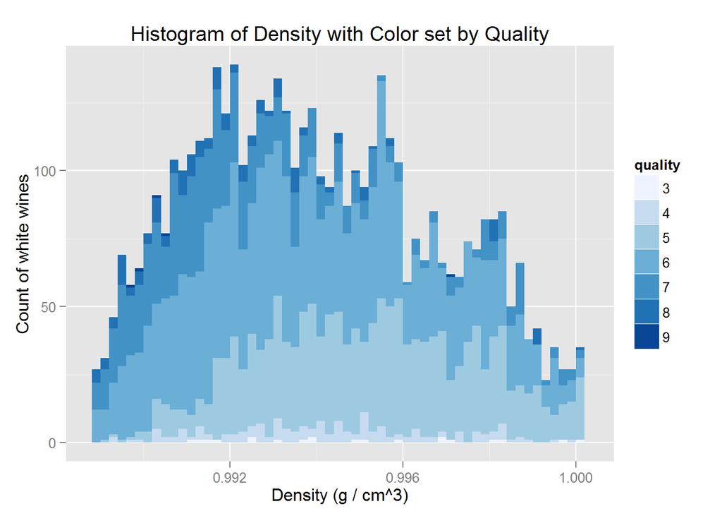

### Description Two

This histogram provides a good visualization of the relationship between density and quality. Since there are some outliers for density, I removed the top and bottom 1% from the chart.

Since the color is set by the quality, each quality value has a unique impact on the overall histogram, and I can draw insight from these distributions. The center of the distributions shift to the left as the color changes darker blue. This means that the main concentration of density values decreases as the quality increases.

Summarizing the data by quality supports this assertion: The median density steadily decreases from 0.9953 to 0.9903 as the quality value increases from “poor” (5) to “good” (9). This is similar to what I noticed when evaluating the correlation between alcohol and quality in the last plot. I realized that I needed to investigate the relationship between density and alcohol.

### Plot Three

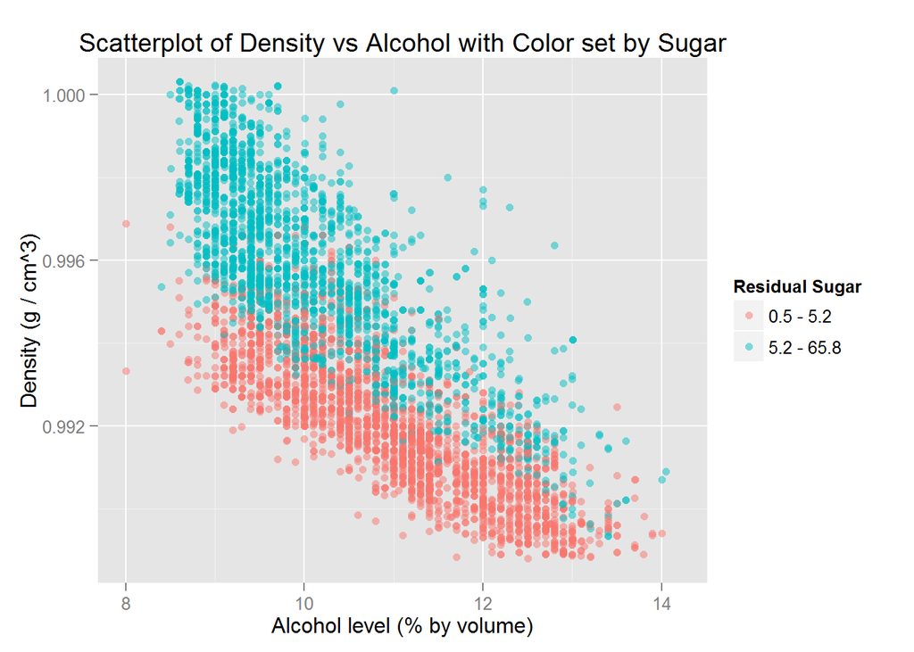

### Description Three

This plot reflects the relationship between density, alcohol, and sugar in a single visualization. I split the residual sugar values into two buckets delineated by the median value of 5.2 in order to see the trends more clearly.

I can see that as the alcohol level increases, the density decreases because the scatterplot has a downward trend to the right. This suggests that alcohol is one of the less dense ingredients in wine. Also, the sugar red/blue coloring shows that as the sugar increases, the density also increases, since the blue dots are higher on the chart than the red dots. This suggests that sugar is one of the more dense ingredients in wine. Thirdly, there is a heavier concentration of blue dots on the left side of the chart than the right side, which means that lower alcohol levels are associated with higher levels of sugar. The correlation values between these variables support all of these insights from the chart.

I investigated the wine-making process in order to better understand the relationship between these features. Fermentation converts the sugars to alcohol, so the conclusions from this chart make logical sense. This was interesting to me, because the data helped me understand how wine is created.

# Reflection

To put it simply, this exercise taught me how to explore data. I now know how to use an extensive library of new tools in R to explore any set of data. I quickly learned to apply basic functions like dim, str, table, and renaming/adjusting fields. I also applied more advanced functions such as summarize, groupby, ggpairs, and quantile ranges. I became much more proficient with plotting, including scatterplots, histograms, boxplots, and line graphs, while adjusting a multitude of parameters throughout my charts, such as transparency, jitter, smoothing, labeling, limiting axes, and facet wrapping. I concluded the analysis by applying basic linear modeling. On top of all that, I now know how to use R markdown to create professional-looking writeups.

The multivariate analysis proved to be the most challenging section for me. When an analyst is evaluating more than two variables at once, there are countless possibilities for structuring the visualization and there is a multitude of variable combinations to investigate. I was able to overcome this difficulty by realizing that my analysis in this section should build on the analysis from the prior sections. In other words, if I found some interesting relationships in the bivariate section, I should investigate that same relationship further using another variable in the multivariate section. Finding a best fit model as a predictor of wine quality was also challenging.

I found success in evaluating particular relationships with multiple R tools. Part of this seemed repetitive at the time, because a lot of the insights were the same using different chart types and analysis tools. However, I thought this was valuable experience for a couple reasons. One reason is that there may be new insights when the data is displayed differently, and the other reason is that it gave me the opportunity to practice all of the functions that I had learned during the course.

There are plenty of ways to improve my analysis on the white wine data. The most obvious example to me is to achieve a better model for predicting the quality based on the other features. My linear model had high residuals and low R2. I would need to enhance my model by transforming features or using a non-linear model. Also, I did not spend much time evaluating ratios of variables (e.g. quality / alcohol) but there may be some useful insights there. Thirdly, many of my key decisions in this analysis were based on investigating the relationships between correlating variables, but there are certain non-correlating that still warrant additional investigation. I would also be interested in enriching this analysis by evaluating the red wine sample data and looking at the similarities and differences.

Reflecting on this analysis exercise, I realize that the most valuable part was getting practice with applying thoughtful reasoning and drawing conclusions on a brand new dataset that I knew little about. I discovered useful insight about wines simply by evaluating the data, and I look forward to continuing to develop my skills on additional datasets.